# Risk Factor Analysis

## Outcome Variable

**Outcome Variable:** stunted

## Predictor Variables

**Intervention Variable:** tr

**Adjustment Set:**

unadjusted

## Stratifying Variables

The analysis was stratified on these variable(s):

- agecat
- studyid
- country
- intXmbmi

## Data Summary

| agecat | studyid | country | intXmbmi | stunted | n_cell | n |
| --- | --- | --- | --- | --- | --- | --- |
| Birth | iLiNS_DYADM_LNS | MALAWI | Underweight_Birth | 0 | 0 | 1 |
| Birth | iLiNS_DYADM_LNS | MALAWI | Underweight_Birth | 1 | 1 | 1 |
| Birth | ki1000125-AgaKhanUniv | PAKISTAN | Overweight or Obese_Birth | 0 | 4 | 4 |
| Birth | ki1000125-AgaKhanUniv | PAKISTAN | Overweight or Obese_Birth | 1 | 0 | 4 |
| Birth | ki1000304b-SAS-CompFeed | INDIA | Normal weight_Birth | 0 | 43 | 60 |
| Birth | ki1000304b-SAS-CompFeed | INDIA | Normal weight_Birth | 1 | 17 | 60 |
| Birth | ki1000304b-SAS-CompFeed | INDIA | Underweight_Birth | 0 | 16 | 27 |
| Birth | ki1000304b-SAS-CompFeed | INDIA | Underweight_Birth | 1 | 11 | 27 |
| Birth | ki1000304b-SAS-CompFeed | INDIA | Overweight or Obese_Birth | 0 | 2 | 2 |
| Birth | ki1000304b-SAS-CompFeed | INDIA | Overweight or Obese_Birth | 1 | 0 | 2 |
| Birth | ki1119695-PROBIT | BELARUS | Normal weight_Birth | 0 | 8129 | 8149 |
| Birth | ki1119695-PROBIT | BELARUS | Normal weight_Birth | 1 | 20 | 8149 |
| Birth | ki1119695-PROBIT | BELARUS | Underweight_Birth | 0 | 522 | 523 |
| Birth | ki1119695-PROBIT | BELARUS | Underweight_Birth | 1 | 1 | 523 |
| Birth | ki1119695-PROBIT | BELARUS | Overweight or Obese_Birth | 0 | 5039 | 5051 |
| Birth | ki1119695-PROBIT | BELARUS | Overweight or Obese_Birth | 1 | 12 | 5051 |
| Birth | ki1126311-ZVITAMBO | ZIMBABWE | Normal weight_Birth | 0 | 5912 | 6598 |
| Birth | ki1126311-ZVITAMBO | ZIMBABWE | Normal weight_Birth | 1 | 686 | 6598 |
| Birth | ki1126311-ZVITAMBO | ZIMBABWE | Underweight_Birth | 0 | 432 | 510 |
| Birth | ki1126311-ZVITAMBO | ZIMBABWE | Underweight_Birth | 1 | 78 | 510 |
| Birth | ki1126311-ZVITAMBO | ZIMBABWE | Overweight or Obese_Birth | 0 | 2334 | 2526 |
| Birth | ki1126311-ZVITAMBO | ZIMBABWE | Overweight or Obese_Birth | 1 | 192 | 2526 |
| Birth | ki1148112-iLiNS-DYAD-M | MALAWI | Underweight_Birth | 0 | 0 | 1 |
| Birth | ki1148112-iLiNS-DYAD-M | MALAWI | Underweight_Birth | 1 | 1 | 1 |
| 6 months | iLiNS_DYADM_LNS | MALAWI | Normal weight_6 months | 0 | 2 | 2 |
| 6 months | iLiNS_DYADM_LNS | MALAWI | Normal weight_6 months | 1 | 0 | 2 |
| 6 months | iLiNS_DYADM_LNS | MALAWI | Underweight_6 months | 0 | 0 | 1 |
| 6 months | iLiNS_DYADM_LNS | MALAWI | Underweight_6 months | 1 | 1 | 1 |
| 6 months | ki1000110-WASH-Bangladesh | BANGLADESH | Normal weight_6 months | 0 | 378 | 432 |
| 6 months | ki1000110-WASH-Bangladesh | BANGLADESH | Normal weight_6 months | 1 | 54 | 432 |

[output cut: 100 more lines]

The following strata were considered:

- agecat: 24 months, studyid: ki1000110-WASH-Bangladesh, country: BANGLADESH, intXmbmi: Normal weight_24 months
- agecat: 24 months, studyid: ki1000110-WASH-Bangladesh, country: BANGLADESH, intXmbmi: Overweight or Obese_24 months
- agecat: 24 months, studyid: ki1000110-WASH-Bangladesh, country: BANGLADESH, intXmbmi: Underweight_24 months
- agecat: 24 months, studyid: ki1017093b-PROVIDE, country: BANGLADESH, intXmbmi: Normal weight_24 months
- agecat: 24 months, studyid: ki1066203-TanzaniaChild2, country: TANZANIA, UNITED REPUBLIC OF, intXmbmi: Normal weight_24 months
- agecat: 24 months, studyid: ki1066203-TanzaniaChild2, country: TANZANIA, UNITED REPUBLIC OF, intXmbmi: Overweight or Obese_24 months
- agecat: 24 months, studyid: ki1112895-Burkina Faso Zn, country: BURKINA FASO, intXmbmi: Normal weight_24 months
- agecat: 24 months, studyid: ki1112895-Burkina Faso Zn, country: BURKINA FASO, intXmbmi: Overweight or Obese_24 months
- agecat: 24 months, studyid: ki1112895-Burkina Faso Zn, country: BURKINA FASO, intXmbmi: Underweight_24 months
- agecat: 24 months, studyid: ki1119695-PROBIT, country: BELARUS, intXmbmi: Normal weight_24 months
- agecat: 24 months, studyid: ki1119695-PROBIT, country: BELARUS, intXmbmi: Overweight or Obese_24 months
- agecat: 24 months, studyid: ki1119695-PROBIT, country: BELARUS, intXmbmi: Underweight_24 months
- agecat: 24 months, studyid: ki1126311-ZVITAMBO, country: ZIMBABWE, intXmbmi: Normal weight_24 months
- agecat: 24 months, studyid: ki1126311-ZVITAMBO, country: ZIMBABWE, intXmbmi: Overweight or Obese_24 months
- agecat: 24 months, studyid: ki1126311-ZVITAMBO, country: ZIMBABWE, intXmbmi: Underweight_24 months
- agecat: 24 months, studyid: ki1148112-iLiNS-DOSE, country: MALAWI, intXmbmi: Normal weight_24 months
- agecat: 24 months, studyid: ki1148112-iLiNS-DOSE, country: MALAWI, intXmbmi: Overweight or Obese_24 months
- agecat: 24 months, studyid: ki1148112-iLiNS-DOSE, country: MALAWI, intXmbmi: Underweight_24 months
- agecat: 24 months, studyid: ki1148112-LCNI-5, country: MALAWI, intXmbmi: Normal weight_24 months
- agecat: 24 months, studyid: ki1148112-LCNI-5, country: MALAWI, intXmbmi: Overweight or Obese_24 months
- agecat: 24 months, studyid: ki1148112-LCNI-5, country: MALAWI, intXmbmi: Underweight_24 months
- agecat: 6 months, studyid: iLiNS_DYADM_LNS, country: MALAWI, intXmbmi: Normal weight_6 months
- agecat: 6 months, studyid: iLiNS_DYADM_LNS, country: MALAWI, intXmbmi: Underweight_6 months
- agecat: 6 months, studyid: ki1000110-WASH-Bangladesh, country: BANGLADESH, intXmbmi: Normal weight_6 months
- agecat: 6 months, studyid: ki1000110-WASH-Bangladesh, country: BANGLADESH, intXmbmi: Overweight or Obese_6 months
- agecat: 6 months, studyid: ki1000110-WASH-Bangladesh, country: BANGLADESH, intXmbmi: Underweight_6 months
- agecat: 6 months, studyid: ki1000125-AgaKhanUniv, country: PAKISTAN, intXmbmi: Overweight or Obese_6 months
- agecat: 6 months, studyid: ki1000304b-SAS-CompFeed, country: INDIA, intXmbmi: Normal weight_6 months
- agecat: 6 months, studyid: ki1000304b-SAS-CompFeed, country: INDIA, intXmbmi: Overweight or Obese_6 months
- agecat: 6 months, studyid: ki1000304b-SAS-CompFeed, country: INDIA, intXmbmi: Underweight_6 months
- agecat: 6 months, studyid: ki1017093b-PROVIDE, country: BANGLADESH, intXmbmi: Normal weight_6 months
- agecat: 6 months, studyid: ki1017093b-PROVIDE, country: BANGLADESH, intXmbmi: Overweight or Obese_6 months
- agecat: 6 months, studyid: ki1017093b-PROVIDE, country: BANGLADESH, intXmbmi: Underweight_6 months
- agecat: 6 months, studyid: ki1066203-TanzaniaChild2, country: TANZANIA, UNITED REPUBLIC OF, intXmbmi: Normal weight_6 months
- agecat: 6 months, studyid: ki1066203-TanzaniaChild2, country: TANZANIA, UNITED REPUBLIC OF, intXmbmi: Overweight or Obese_6 months
- agecat: 6 months, studyid: ki1066203-TanzaniaChild2, country: TANZANIA, UNITED REPUBLIC OF, intXmbmi: Underweight_6 months
- agecat: 6 months, studyid: ki1112895-Burkina Faso Zn, country: BURKINA FASO, intXmbmi: Normal weight_6 months
- agecat: 6 months, studyid: ki1112895-Burkina Faso Zn, country: BURKINA FASO, intXmbmi: Overweight or Obese_6 months
- agecat: 6 months, studyid: ki1112895-Burkina Faso Zn, country: BURKINA FASO, intXmbmi: Underweight_6 months
- agecat: 6 months, studyid: ki1119695-PROBIT, country: BELARUS, intXmbmi: Normal weight_6 months
- agecat: 6 months, studyid: ki1119695-PROBIT, country: BELARUS, intXmbmi: Overweight or Obese_6 months
- agecat: 6 months, studyid: ki1119695-PROBIT, country: BELARUS, intXmbmi: Underweight_6 months
- agecat: 6 months, studyid: ki1126311-ZVITAMBO, country: ZIMBABWE, intXmbmi: Normal weight_6 months
- agecat: 6 months, studyid: ki1126311-ZVITAMBO, country: ZIMBABWE, intXmbmi: Overweight or Obese_6 months
- agecat: 6 months, studyid: ki1126311-ZVITAMBO, country: ZIMBABWE, intXmbmi: Underweight_6 months
- agecat: 6 months, studyid: ki1148112-iLiNS-DOSE, country: MALAWI, intXmbmi: Normal weight_6 months
- agecat: 6 months, studyid: ki1148112-iLiNS-DOSE, country: MALAWI, intXmbmi: Overweight or Obese_6 months
- agecat: 6 months, studyid: ki1148112-iLiNS-DOSE, country: MALAWI, intXmbmi: Underweight_6 months
- agecat: 6 months, studyid: ki1148112-iLiNS-DYAD-M, country: MALAWI, intXmbmi: Normal weight_6 months
- agecat: 6 months, studyid: ki1148112-iLiNS-DYAD-M, country: MALAWI, intXmbmi: Underweight_6 months
- agecat: 6 months, studyid: ki1148112-LCNI-5, country: MALAWI, intXmbmi: Normal weight_6 months
- agecat: 6 months, studyid: ki1148112-LCNI-5, country: MALAWI, intXmbmi: Overweight or Obese_6 months
- agecat: 6 months, studyid: ki1148112-LCNI-5, country: MALAWI, intXmbmi: Underweight_6 months
- agecat: Birth, studyid: iLiNS_DYADM_LNS, country: MALAWI, intXmbmi: Underweight_Birth
- agecat: Birth, studyid: ki1000125-AgaKhanUniv, country: PAKISTAN, intXmbmi: Overweight or Obese_Birth
- agecat: Birth, studyid: ki1000304b-SAS-CompFeed, country: INDIA, intXmbmi: Normal weight_Birth
- agecat: Birth, studyid: ki1000304b-SAS-CompFeed, country: INDIA, intXmbmi: Overweight or Obese_Birth
- agecat: Birth, studyid: ki1000304b-SAS-CompFeed, country: INDIA, intXmbmi: Underweight_Birth
- agecat: Birth, studyid: ki1119695-PROBIT, country: BELARUS, intXmbmi: Normal weight_Birth
- agecat: Birth, studyid: ki1119695-PROBIT, country: BELARUS, intXmbmi: Overweight or Obese_Birth
- agecat: Birth, studyid: ki1119695-PROBIT, country: BELARUS, intXmbmi: Underweight_Birth
- agecat: Birth, studyid: ki1126311-ZVITAMBO, country: ZIMBABWE, intXmbmi: Normal weight_Birth
- agecat: Birth, studyid: ki1126311-ZVITAMBO, country: ZIMBABWE, intXmbmi: Overweight or Obese_Birth
- agecat: Birth, studyid: ki1126311-ZVITAMBO, country: ZIMBABWE, intXmbmi: Underweight_Birth
- agecat: Birth, studyid: ki1148112-iLiNS-DYAD-M, country: MALAWI, intXmbmi: Underweight_Birth

### Dropped Strata

Some strata were dropped due to rare outcomes:

- agecat: Birth, studyid: iLiNS_DYADM_LNS, country: MALAWI, intXmbmi: Underweight_Birth
- agecat: Birth, studyid: ki1000125-AgaKhanUniv, country: PAKISTAN, intXmbmi: Overweight or Obese_Birth
- agecat: Birth, studyid: ki1000304b-SAS-CompFeed, country: INDIA, intXmbmi: Overweight or Obese_Birth
- agecat: Birth, studyid: ki1119695-PROBIT, country: BELARUS, intXmbmi: Underweight_Birth
- agecat: Birth, studyid: ki1148112-iLiNS-DYAD-M, country: MALAWI, intXmbmi: Underweight_Birth
- agecat: 6 months, studyid: iLiNS_DYADM_LNS, country: MALAWI, intXmbmi: Normal weight_6 months
- agecat: 6 months, studyid: iLiNS_DYADM_LNS, country: MALAWI, intXmbmi: Underweight_6 months
- agecat: 6 months, studyid: ki1000110-WASH-Bangladesh, country: BANGLADESH, intXmbmi: Overweight or Obese_6 months
- agecat: 6 months, studyid: ki1000304b-SAS-CompFeed, country: INDIA, intXmbmi: Overweight or Obese_6 months
- agecat: 6 months, studyid: ki1017093b-PROVIDE, country: BANGLADESH, intXmbmi: Underweight_6 months
- agecat: 6 months, studyid: ki1017093b-PROVIDE, country: BANGLADESH, intXmbmi: Overweight or Obese_6 months
- agecat: 6 months, studyid: ki1066203-TanzaniaChild2, country: TANZANIA, UNITED REPUBLIC OF, intXmbmi: Underweight_6 months
- agecat: 6 months, studyid: ki1112895-Burkina Faso Zn, country: BURKINA FASO, intXmbmi: Overweight or Obese_6 months
- agecat: 6 months, studyid: ki1148112-iLiNS-DYAD-M, country: MALAWI, intXmbmi: Normal weight_6 months
- agecat: 6 months, studyid: ki1148112-iLiNS-DYAD-M, country: MALAWI, intXmbmi: Underweight_6 months
- agecat: 24 months, studyid: ki1017093b-PROVIDE, country: BANGLADESH, intXmbmi: Normal weight_24 months
- agecat: 24 months, studyid: ki1066203-TanzaniaChild2, country: TANZANIA, UNITED REPUBLIC OF, intXmbmi: Normal weight_24 months
- agecat: 24 months, studyid: ki1066203-TanzaniaChild2, country: TANZANIA, UNITED REPUBLIC OF, intXmbmi: Overweight or Obese_24 months
- agecat: 24 months, studyid: ki1126311-ZVITAMBO, country: ZIMBABWE, intXmbmi: Underweight_24 months
- agecat: 24 months, studyid: ki1126311-ZVITAMBO, country: ZIMBABWE, intXmbmi: Overweight or Obese_24 months

## Methods Detail

We’re interested in the causal parameters $E[Y_a]$ for all values of $a \in \mathcal{A}$. These parameters represent the mean outcome if, possibly contrary to fact, we intervened to set all units to have $A=a$. Under the randomization and positivity assumptions, these are identified by the statistical parameters $\psi_a=E_W[E_{Y|A,W}(Y|A=a,W)]$. In addition, we’re interested in the mean of $Y$, $E[Y]$ under no intervention (the observed mean). We will estimate these parameters by using SuperLearner to fit the relevant likelihood factors – $E_{Y|A,W}(Y|A=a,W)$ and $p(A=a|W)$, and then updating our likelihood fit using a joint TMLE.

For unadjusted analyses ($W=\{\}$), initial likelihoods were estimated using Lrnr_glm to estimate the simple $E(Y|A)$ and Lrnr_mean to estimate $p(A)$. For adjusted analyses, a small library containing Lrnr_glmnet, Lrnr_xgboost, and Lrnr_mean was used.

Having estimated these parameters, we will then use the delta method to estimate relative risks and attributable risks relative to a prespecified baseline level of $A$.

[output not shown]

# Results Detail

## Results Plots

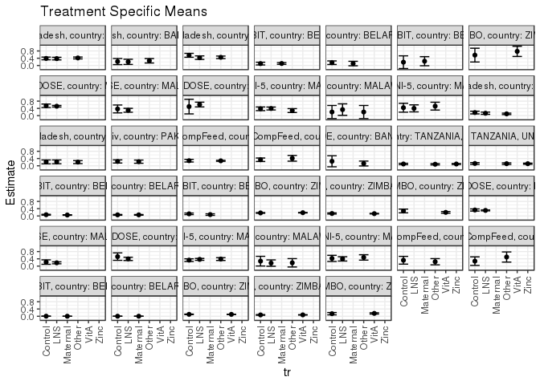

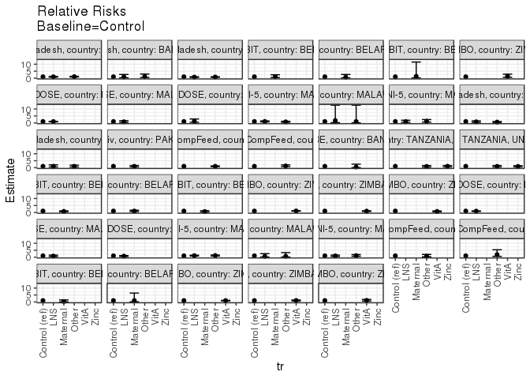

[figure not shown]

[figure not shown]

## Results Table

### Parameter: TSM

| agecat | studyid | country | intXmbmi | intervention_level | baseline_level | estimate | ci_lower | ci_upper |
| --- | --- | --- | --- | --- | --- | --- | --- | --- |
| Birth | ki1000304b-SAS-CompFeed | INDIA | Normal weight_Birth | Control | NA | 0.3225806 | 0.1086976 | 0.5364637 |
| Birth | ki1000304b-SAS-CompFeed | INDIA | Normal weight_Birth | Other | NA | 0.2413793 | 0.0699490 | 0.4128096 |
| Birth | ki1000304b-SAS-CompFeed | INDIA | Underweight_Birth | Control | NA | 0.2727273 | 0.0377409 | 0.5077137 |
| Birth | ki1000304b-SAS-CompFeed | INDIA | Underweight_Birth | Other | NA | 0.5000000 | 0.2198039 | 0.7801961 |
| Birth | ki1119695-PROBIT | BELARUS | Normal weight_Birth | Control | NA | 0.0038023 | 0.0016507 | 0.0059538 |
| Birth | ki1119695-PROBIT | BELARUS | Normal weight_Birth | Maternal | NA | 0.0011893 | -0.0005275 | 0.0029062 |
| Birth | ki1119695-PROBIT | BELARUS | Overweight or Obese_Birth | Control | NA | 0.0024067 | -0.0007809 | 0.0055943 |
| Birth | ki1119695-PROBIT | BELARUS | Overweight or Obese_Birth | Maternal | NA | 0.0023456 | -0.0007789 | 0.0054700 |
| Birth | ki1126311-ZVITAMBO | ZIMBABWE | Normal weight_Birth | Control | NA | 0.1051033 | 0.0902863 | 0.1199203 |
| Birth | ki1126311-ZVITAMBO | ZIMBABWE | Normal weight_Birth | VitA | NA | 0.1035945 | 0.0951064 | 0.1120826 |
| Birth | ki1126311-ZVITAMBO | ZIMBABWE | Underweight_Birth | Control | NA | 0.1403509 | 0.0765260 | 0.2041758 |
| Birth | ki1126311-ZVITAMBO | ZIMBABWE | Underweight_Birth | VitA | NA | 0.1565657 | 0.1207395 | 0.1923918 |
| Birth | ki1126311-ZVITAMBO | ZIMBABWE | Overweight or Obese_Birth | Control | NA | 0.0738363 | 0.0532978 | 0.0943748 |
| Birth | ki1126311-ZVITAMBO | ZIMBABWE | Overweight or Obese_Birth | VitA | NA | 0.0767210 | 0.0647608 | 0.0886812 |
| 6 months | ki1000110-WASH-Bangladesh | BANGLADESH | Normal weight_6 months | Control | NA | 0.1700000 | 0.0962920 | 0.2437080 |
| 6 months | ki1000110-WASH-Bangladesh | BANGLADESH | Normal weight_6 months | LNS | NA | 0.1333333 | 0.0724419 | 0.1942248 |
| 6 months | ki1000110-WASH-Bangladesh | BANGLADESH | Normal weight_6 months | Other | NA | 0.0990566 | 0.0587966 | 0.1393166 |
| 6 months | ki1000110-WASH-Bangladesh | BANGLADESH | Underweight_6 months | Control | NA | 0.2142857 | 0.1065587 | 0.3220127 |
| 6 months | ki1000110-WASH-Bangladesh | BANGLADESH | Underweight_6 months | LNS | NA | 0.2166667 | 0.1121746 | 0.3211587 |
| 6 months | ki1000110-WASH-Bangladesh | BANGLADESH | Underweight_6 months | Other | NA | 0.2043011 | 0.1221605 | 0.2864417 |
| 6 months | ki1000125-AgaKhanUniv | PAKISTAN | Overweight or Obese_6 months | Control | NA | 0.2395833 | 0.1539683 | 0.3251984 |
| 6 months | ki1000125-AgaKhanUniv | PAKISTAN | Overweight or Obese_6 months | Maternal | NA | 0.2272727 | 0.1394763 | 0.3150692 |
| 6 months | ki1000304b-SAS-CompFeed | INDIA | Normal weight_6 months | Control | NA | 0.2817680 | 0.2092159 | 0.3543200 |
| 6 months | ki1000304b-SAS-CompFeed | INDIA | Normal weight_6 months | Other | NA | 0.2744186 | 0.2461553 | 0.3026819 |
| 6 months | ki1000304b-SAS-CompFeed | INDIA | Underweight_6 months | Control | NA | 0.3333333 | 0.2378865 | 0.4287802 |
| 6 months | ki1000304b-SAS-CompFeed | INDIA | Underweight_6 months | Other | NA | 0.4126984 | 0.2546667 | 0.5707302 |
| 6 months | ki1017093b-PROVIDE | BANGLADESH | Normal weight_6 months | Control | NA | 0.2500000 | -0.0548582 | 0.5548582 |
| 6 months | ki1017093b-PROVIDE | BANGLADESH | Normal weight_6 months | Other | NA | 0.1250000 | -0.0094298 | 0.2594298 |
| 6 months | ki1066203-TanzaniaChild2 | TANZANIA, UNITED REPUBLIC OF | Normal weight_6 months | Control | NA | 0.1004367 | 0.0614831 | 0.1393902 |
| 6 months | ki1066203-TanzaniaChild2 | TANZANIA, UNITED REPUBLIC OF | Normal weight_6 months | Other | NA | 0.0857143 | 0.0478299 | 0.1235987 |

[output cut: 63 more lines]

### Parameter: E(Y)

| agecat | studyid | country | intXmbmi | intervention_level | baseline_level | estimate | ci_lower | ci_upper |
| --- | --- | --- | --- | --- | --- | --- | --- | --- |
| Birth | ki1000304b-SAS-CompFeed | INDIA | Normal weight_Birth | NA | NA | 0.2833333 | 0.1434542 | 0.4232125 |
| Birth | ki1000304b-SAS-CompFeed | INDIA | Underweight_Birth | NA | NA | 0.4074074 | 0.2051492 | 0.6096656 |
| Birth | ki1119695-PROBIT | BELARUS | Normal weight_Birth | NA | NA | 0.0024543 | 0.0009988 | 0.0039098 |
| Birth | ki1119695-PROBIT | BELARUS | Overweight or Obese_Birth | NA | NA | 0.0023758 | 0.0001450 | 0.0046065 |
| Birth | ki1126311-ZVITAMBO | ZIMBABWE | Normal weight_Birth | NA | NA | 0.1039709 | 0.0966056 | 0.1113362 |
| Birth | ki1126311-ZVITAMBO | ZIMBABWE | Underweight_Birth | NA | NA | 0.1529412 | 0.1216726 | 0.1842098 |
| Birth | ki1126311-ZVITAMBO | ZIMBABWE | Overweight or Obese_Birth | NA | NA | 0.0760095 | 0.0656727 | 0.0863463 |
| 6 months | ki1000110-WASH-Bangladesh | BANGLADESH | Normal weight_6 months | NA | NA | 0.1250000 | 0.0937774 | 0.1562226 |
| 6 months | ki1000110-WASH-Bangladesh | BANGLADESH | Underweight_6 months | NA | NA | 0.2105263 | 0.1551227 | 0.2659300 |
| 6 months | ki1000125-AgaKhanUniv | PAKISTAN | Overweight or Obese_6 months | NA | NA | 0.2336957 | 0.1723832 | 0.2950081 |
| 6 months | ki1000304b-SAS-CompFeed | INDIA | Normal weight_6 months | NA | NA | 0.2777778 | 0.2413281 | 0.3142275 |
| 6 months | ki1000304b-SAS-CompFeed | INDIA | Underweight_6 months | NA | NA | 0.3720930 | 0.2781350 | 0.4660511 |
| 6 months | ki1017093b-PROVIDE | BANGLADESH | Normal weight_6 months | NA | NA | 0.1562500 | 0.0284343 | 0.2840657 |
| 6 months | ki1066203-TanzaniaChild2 | TANZANIA, UNITED REPUBLIC OF | Normal weight_6 months | NA | NA | 0.0961313 | 0.0763382 | 0.1159244 |
| 6 months | ki1066203-TanzaniaChild2 | TANZANIA, UNITED REPUBLIC OF | Overweight or Obese_6 months | NA | NA | 0.1184713 | 0.0958502 | 0.1410925 |
| 6 months | ki1119695-PROBIT | BELARUS | Normal weight_6 months | NA | NA | 0.0597750 | 0.0453286 | 0.0742213 |
| 6 months | ki1119695-PROBIT | BELARUS | Underweight_6 months | NA | NA | 0.0952381 | 0.0635513 | 0.1269249 |
| 6 months | ki1119695-PROBIT | BELARUS | Overweight or Obese_6 months | NA | NA | 0.0601266 | 0.0458796 | 0.0743736 |
| 6 months | ki1126311-ZVITAMBO | ZIMBABWE | Normal weight_6 months | NA | NA | 0.1759505 | 0.1648535 | 0.1870475 |
| 6 months | ki1126311-ZVITAMBO | ZIMBABWE | Underweight_6 months | NA | NA | 0.2130178 | 0.1693035 | 0.2567320 |
| 6 months | ki1126311-ZVITAMBO | ZIMBABWE | Overweight or Obese_6 months | NA | NA | 0.1292861 | 0.1136907 | 0.1448815 |
| 6 months | ki1148112-iLiNS-DOSE | MALAWI | Normal weight_6 months | NA | NA | 0.3090909 | 0.2860031 | 0.3321787 |
| 6 months | ki1148112-iLiNS-DOSE | MALAWI | Underweight_6 months | NA | NA | 0.4191176 | 0.3358851 | 0.5023502 |
| 6 months | ki1148112-iLiNS-DOSE | MALAWI | Overweight or Obese_6 months | NA | NA | 0.1885246 | 0.1393471 | 0.2377021 |
| 6 months | ki1148112-LCNI-5 | MALAWI | Normal weight_6 months | NA | NA | 0.3640553 | 0.3270653 | 0.4010453 |
| 6 months | ki1148112-LCNI-5 | MALAWI | Underweight_6 months | NA | NA | 0.4275862 | 0.3467820 | 0.5083904 |
| 6 months | ki1148112-LCNI-5 | MALAWI | Overweight or Obese_6 months | NA | NA | 0.2000000 | 0.0744618 | 0.3255382 |
| 24 months | ki1000110-WASH-Bangladesh | BANGLADESH | Normal weight_24 months | NA | NA | 0.3991416 | 0.3628113 | 0.4354720 |
| 24 months | ki1000110-WASH-Bangladesh | BANGLADESH | Underweight_24 months | NA | NA | 0.4687500 | 0.4187732 | 0.5187268 |
| 24 months | ki1000110-WASH-Bangladesh | BANGLADESH | Overweight or Obese_24 months | NA | NA | 0.2330097 | 0.1509689 | 0.3150505 |
| 24 months | ki1119695-PROBIT | BELARUS | Normal weight_24 months | NA | NA | 0.1086519 | 0.0656960 | 0.1516078 |
| 24 months | ki1119695-PROBIT | BELARUS | Underweight_24 months | NA | NA | 0.2142857 | 0.0104049 | 0.4181666 |
| 24 months | ki1119695-PROBIT | BELARUS | Overweight or Obese_24 months | NA | NA | 0.1266234 | 0.0453237 | 0.2079231 |
| 24 months | ki1126311-ZVITAMBO | ZIMBABWE | Normal weight_24 months | NA | NA | 0.6875000 | 0.4529347 | 0.9220653 |
| 24 months | ki1148112-iLiNS-DOSE | MALAWI | Normal weight_24 months | NA | NA | 0.5225806 | 0.4832320 | 0.5619293 |
| 24 months | ki1148112-iLiNS-DOSE | MALAWI | Underweight_24 months | NA | NA | 0.6000000 | 0.4749949 | 0.7250051 |
| 24 months | ki1148112-iLiNS-DOSE | MALAWI | Overweight or Obese_24 months | NA | NA | 0.3111111 | 0.2149310 | 0.4072913 |
| 24 months | ki1148112-LCNI-5 | MALAWI | Normal weight_24 months | NA | NA | 0.3630363 | 0.3088016 | 0.4172710 |
| 24 months | ki1148112-LCNI-5 | MALAWI | Underweight_24 months | NA | NA | 0.4516129 | 0.3267280 | 0.5764978 |
| 24 months | ki1148112-LCNI-5 | MALAWI | Overweight or Obese_24 months | NA | NA | 0.2631579 | 0.0597315 | 0.4665843 |

### Parameter: RR

| agecat | studyid | country | intXmbmi | intervention_level | baseline_level | estimate | ci_lower | ci_upper |
| --- | --- | --- | --- | --- | --- | --- | --- | --- |
| Birth | ki1000304b-SAS-CompFeed | INDIA | Normal weight_Birth | Control | Control | 1.0000000 | 1.0000000 | 1.000000 |
| Birth | ki1000304b-SAS-CompFeed | INDIA | Normal weight_Birth | Other | Control | 0.7482759 | 0.2831850 | 1.977212 |
| Birth | ki1000304b-SAS-CompFeed | INDIA | Underweight_Birth | Control | Control | 1.0000000 | 1.0000000 | 1.000000 |
| Birth | ki1000304b-SAS-CompFeed | INDIA | Underweight_Birth | Other | Control | 1.8333333 | 0.6277918 | 5.353863 |
| Birth | ki1119695-PROBIT | BELARUS | Normal weight_Birth | Control | Control | 1.0000000 | 1.0000000 | 1.000000 |
| Birth | ki1119695-PROBIT | BELARUS | Normal weight_Birth | Maternal | Control | 0.3127973 | 0.0661912 | 1.478174 |
| Birth | ki1119695-PROBIT | BELARUS | Overweight or Obese_Birth | Control | Control | 1.0000000 | 1.0000000 | 1.000000 |
| Birth | ki1119695-PROBIT | BELARUS | Overweight or Obese_Birth | Maternal | Control | 0.9745895 | 0.1489103 | 6.378502 |
| Birth | ki1126311-ZVITAMBO | ZIMBABWE | Normal weight_Birth | Control | Control | 1.0000000 | 1.0000000 | 1.000000 |
| Birth | ki1126311-ZVITAMBO | ZIMBABWE | Normal weight_Birth | VitA | Control | 0.9856449 | 0.8373472 | 1.160207 |
| Birth | ki1126311-ZVITAMBO | ZIMBABWE | Underweight_Birth | Control | Control | 1.0000000 | 1.0000000 | 1.000000 |
| Birth | ki1126311-ZVITAMBO | ZIMBABWE | Underweight_Birth | VitA | Control | 1.1155303 | 0.6704887 | 1.855971 |
| Birth | ki1126311-ZVITAMBO | ZIMBABWE | Overweight or Obese_Birth | Control | Control | 1.0000000 | 1.0000000 | 1.000000 |
| Birth | ki1126311-ZVITAMBO | ZIMBABWE | Overweight or Obese_Birth | VitA | Control | 1.0390687 | 0.7553733 | 1.429312 |
| 6 months | ki1000110-WASH-Bangladesh | BANGLADESH | Normal weight_6 months | Control | Control | 1.0000000 | 1.0000000 | 1.000000 |
| 6 months | ki1000110-WASH-Bangladesh | BANGLADESH | Normal weight_6 months | LNS | Control | 0.7843137 | 0.4178350 | 1.472227 |
| 6 months | ki1000110-WASH-Bangladesh | BANGLADESH | Normal weight_6 months | Other | Control | 0.5826859 | 0.3216168 | 1.055675 |
| 6 months | ki1000110-WASH-Bangladesh | BANGLADESH | Underweight_6 months | Control | Control | 1.0000000 | 1.0000000 | 1.000000 |
| 6 months | ki1000110-WASH-Bangladesh | BANGLADESH | Underweight_6 months | LNS | Control | 1.0111111 | 0.5037887 | 2.029314 |
| 6 months | ki1000110-WASH-Bangladesh | BANGLADESH | Underweight_6 months | Other | Control | 0.9534050 | 0.5008537 | 1.814863 |
| 6 months | ki1000125-AgaKhanUniv | PAKISTAN | Overweight or Obese_6 months | Control | Control | 1.0000000 | 1.0000000 | 1.000000 |
| 6 months | ki1000125-AgaKhanUniv | PAKISTAN | Overweight or Obese_6 months | Maternal | Control | 0.9486166 | 0.5604632 | 1.605589 |
| 6 months | ki1000304b-SAS-CompFeed | INDIA | Normal weight_6 months | Control | Control | 1.0000000 | 1.0000000 | 1.000000 |
| 6 months | ki1000304b-SAS-CompFeed | INDIA | Normal weight_6 months | Other | Control | 0.9739170 | 0.7382507 | 1.284813 |
| 6 months | ki1000304b-SAS-CompFeed | INDIA | Underweight_6 months | Control | Control | 1.0000000 | 1.0000000 | 1.000000 |
| 6 months | ki1000304b-SAS-CompFeed | INDIA | Underweight_6 months | Other | Control | 1.2380952 | 0.7670739 | 1.998347 |
| 6 months | ki1017093b-PROVIDE | BANGLADESH | Normal weight_6 months | Control | Control | 1.0000000 | 1.0000000 | 1.000000 |
| 6 months | ki1017093b-PROVIDE | BANGLADESH | Normal weight_6 months | Other | Control | 0.5000000 | 0.0983662 | 2.541522 |
| 6 months | ki1066203-TanzaniaChild2 | TANZANIA, UNITED REPUBLIC OF | Normal weight_6 months | Control | Control | 1.0000000 | 1.0000000 | 1.000000 |
| 6 months | ki1066203-TanzaniaChild2 | TANZANIA, UNITED REPUBLIC OF | Normal weight_6 months | Other | Control | 0.8534161 | 0.4740076 | 1.536514 |

[output cut: 63 more lines]

### Parameter: PAR

| agecat | studyid | country | intXmbmi | intervention_level | baseline_level | estimate | ci_lower | ci_upper |
| --- | --- | --- | --- | --- | --- | --- | --- | --- |
| Birth | ki1000304b-SAS-CompFeed | INDIA | Normal weight_Birth | Control | NA | -0.0392473 | -0.1766002 | 0.0981056 |
| Birth | ki1000304b-SAS-CompFeed | INDIA | Underweight_Birth | Control | NA | 0.1346801 | -0.0710875 | 0.3404478 |
| Birth | ki1119695-PROBIT | BELARUS | Normal weight_Birth | Control | NA | -0.0013480 | -0.0027999 | 0.0001039 |
| Birth | ki1119695-PROBIT | BELARUS | Overweight or Obese_Birth | Control | NA | -0.0000310 | -0.0022913 | 0.0022294 |
| Birth | ki1126311-ZVITAMBO | ZIMBABWE | Normal weight_Birth | Control | NA | -0.0011324 | -0.0139485 | 0.0116837 |
| Birth | ki1126311-ZVITAMBO | ZIMBABWE | Underweight_Birth | Control | NA | 0.0125903 | -0.0442445 | 0.0694251 |
| Birth | ki1126311-ZVITAMBO | ZIMBABWE | Overweight or Obese_Birth | Control | NA | 0.0021732 | -0.0157322 | 0.0200786 |
| 6 months | ki1000110-WASH-Bangladesh | BANGLADESH | Normal weight_6 months | Control | NA | -0.0450000 | -0.1073899 | 0.0173899 |
| 6 months | ki1000110-WASH-Bangladesh | BANGLADESH | Underweight_6 months | Control | NA | -0.0037594 | -0.0957141 | 0.0881953 |
| 6 months | ki1000125-AgaKhanUniv | PAKISTAN | Overweight or Obese_6 months | Control | NA | -0.0058877 | -0.0645436 | 0.0527683 |
| 6 months | ki1000304b-SAS-CompFeed | INDIA | Normal weight_6 months | Control | NA | -0.0039902 | -0.0464645 | 0.0384841 |
| 6 months | ki1000304b-SAS-CompFeed | INDIA | Underweight_6 months | Control | NA | 0.0387597 | -0.0534432 | 0.1309625 |
| 6 months | ki1017093b-PROVIDE | BANGLADESH | Normal weight_6 months | Control | NA | -0.0937500 | -0.3443615 | 0.1568615 |
| 6 months | ki1066203-TanzaniaChild2 | TANZANIA, UNITED REPUBLIC OF | Normal weight_6 months | Control | NA | -0.0043054 | -0.0373874 | 0.0287767 |
| 6 months | ki1066203-TanzaniaChild2 | TANZANIA, UNITED REPUBLIC OF | Overweight or Obese_6 months | Control | NA | -0.0091882 | -0.0504049 | 0.0320284 |
| 6 months | ki1119695-PROBIT | BELARUS | Normal weight_6 months | Control | NA | -0.0078620 | -0.0214989 | 0.0057749 |
| 6 months | ki1119695-PROBIT | BELARUS | Underweight_6 months | Control | NA | -0.0213538 | -0.0542008 | 0.0114931 |
| 6 months | ki1119695-PROBIT | BELARUS | Overweight or Obese_6 months | Control | NA | -0.0002221 | -0.0142315 | 0.0137873 |
| 6 months | ki1126311-ZVITAMBO | ZIMBABWE | Normal weight_6 months | Control | NA | 0.0094307 | -0.0094701 | 0.0283314 |
| 6 months | ki1126311-ZVITAMBO | ZIMBABWE | Underweight_6 months | Control | NA | -0.0609549 | -0.1496932 | 0.0277835 |
| 6 months | ki1126311-ZVITAMBO | ZIMBABWE | Overweight or Obese_6 months | Control | NA | -0.0066586 | -0.0345142 | 0.0211970 |
| 6 months | ki1148112-iLiNS-DOSE | MALAWI | Normal weight_6 months | Control | NA | -0.0189091 | -0.0720295 | 0.0342113 |
| 6 months | ki1148112-iLiNS-DOSE | MALAWI | Underweight_6 months | Control | NA | -0.1026215 | -0.2889322 | 0.0836893 |
| 6 months | ki1148112-iLiNS-DOSE | MALAWI | Overweight or Obese_6 months | Control | NA | -0.0336976 | -0.1421830 | 0.0747877 |
| 6 months | ki1148112-LCNI-5 | MALAWI | Normal weight_6 months | Control | NA | 0.0347870 | -0.0279736 | 0.0975476 |
| 6 months | ki1148112-LCNI-5 | MALAWI | Underweight_6 months | Control | NA | 0.0033438 | -0.1454126 | 0.1521001 |
| 6 months | ki1148112-LCNI-5 | MALAWI | Overweight or Obese_6 months | Control | NA | -0.0727273 | -0.2911979 | 0.1457434 |
| 24 months | ki1000110-WASH-Bangladesh | BANGLADESH | Normal weight_24 months | Control | NA | 0.0112628 | -0.0538689 | 0.0763946 |
| 24 months | ki1000110-WASH-Bangladesh | BANGLADESH | Underweight_24 months | Control | NA | -0.0922256 | -0.1877506 | 0.0032994 |
| 24 months | ki1000110-WASH-Bangladesh | BANGLADESH | Overweight or Obese_24 months | Control | NA | 0.0156184 | -0.1347476 | 0.1659844 |
| 24 months | ki1119695-PROBIT | BELARUS | Normal weight_24 months | Control | NA | 0.0033888 | -0.0445343 | 0.0513118 |
| 24 months | ki1119695-PROBIT | BELARUS | Underweight_24 months | Control | NA | 0.0324675 | -0.2286947 | 0.2936297 |
| 24 months | ki1119695-PROBIT | BELARUS | Overweight or Obese_24 months | Control | NA | -0.0260484 | -0.1162885 | 0.0641917 |
| 24 months | ki1126311-ZVITAMBO | ZIMBABWE | Normal weight_24 months | Control | NA | 0.1160714 | -0.1540031 | 0.3861459 |
| 24 months | ki1148112-iLiNS-DOSE | MALAWI | Normal weight_24 months | Control | NA | -0.0211087 | -0.1090674 | 0.0668501 |
| 24 months | ki1148112-iLiNS-DOSE | MALAWI | Underweight_24 months | Control | NA | 0.1000000 | -0.2818969 | 0.4818969 |
| 24 months | ki1148112-iLiNS-DOSE | MALAWI | Overweight or Obese_24 months | Control | NA | -0.0573099 | -0.2489807 | 0.1343608 |
| 24 months | ki1148112-LCNI-5 | MALAWI | Normal weight_24 months | Control | NA | -0.0147415 | -0.0985730 | 0.0690901 |
| 24 months | ki1148112-LCNI-5 | MALAWI | Underweight_24 months | Control | NA | 0.0141129 | -0.1972030 | 0.2254288 |
| 24 months | ki1148112-LCNI-5 | MALAWI | Overweight or Obese_24 months | Control | NA | 0.0631579 | -0.2575376 | 0.3838534 |

### Parameter: PAF

| agecat | studyid | country | intXmbmi | intervention_level | baseline_level | estimate | ci_lower | ci_upper |
| --- | --- | --- | --- | --- | --- | --- | --- | --- |
| Birth | ki1000304b-SAS-CompFeed | INDIA | Normal weight_Birth | Control | NA | -0.1385199 | -0.7302482 | 0.2508430 |
| Birth | ki1000304b-SAS-CompFeed | INDIA | Underweight_Birth | Control | NA | 0.3305785 | -0.3622380 | 0.6710376 |
| Birth | ki1119695-PROBIT | BELARUS | Normal weight_Birth | Control | NA | -0.5492395 | -1.3531587 | -0.0199666 |
| Birth | ki1119695-PROBIT | BELARUS | Overweight or Obese_Birth | Control | NA | -0.0130365 | -1.5911648 | 0.6039453 |
| Birth | ki1126311-ZVITAMBO | ZIMBABWE | Normal weight_Birth | Control | NA | -0.0108913 | -0.1419861 | 0.1051544 |
| Birth | ki1126311-ZVITAMBO | ZIMBABWE | Underweight_Birth | Control | NA | 0.0823212 | -0.3754244 | 0.3877276 |
| Birth | ki1126311-ZVITAMBO | ZIMBABWE | Overweight or Obese_Birth | Control | NA | 0.0285915 | -0.2379605 | 0.2377508 |
| 6 months | ki1000110-WASH-Bangladesh | BANGLADESH | Normal weight_6 months | Control | NA | -0.3600000 | -0.9558491 | 0.0543238 |
| 6 months | ki1000110-WASH-Bangladesh | BANGLADESH | Underweight_6 months | Control | NA | -0.0178571 | -0.5633174 | 0.3372855 |
| 6 months | ki1000125-AgaKhanUniv | PAKISTAN | Overweight or Obese_6 months | Control | NA | -0.0251938 | -0.3095384 | 0.1974101 |
| 6 months | ki1000304b-SAS-CompFeed | INDIA | Normal weight_6 months | Control | NA | -0.0143646 | -0.1778983 | 0.1264648 |
| 6 months | ki1000304b-SAS-CompFeed | INDIA | Underweight_6 months | Control | NA | 0.1041667 | -0.1664297 | 0.3119882 |
| 6 months | ki1017093b-PROVIDE | BANGLADESH | Normal weight_6 months | Control | NA | -0.6000000 | -3.2765293 | 0.4013837 |
| 6 months | ki1066203-TanzaniaChild2 | TANZANIA, UNITED REPUBLIC OF | Normal weight_6 months | Control | NA | -0.0447865 | -0.4522333 | 0.2483448 |
| 6 months | ki1066203-TanzaniaChild2 | TANZANIA, UNITED REPUBLIC OF | Overweight or Obese_6 months | Control | NA | -0.0775566 | -0.4878794 | 0.2196086 |
| 6 months | ki1119695-PROBIT | BELARUS | Normal weight_6 months | Control | NA | -0.1315270 | -0.3774522 | 0.0704916 |
| 6 months | ki1119695-PROBIT | BELARUS | Underweight_6 months | Control | NA | -0.2242152 | -0.6451003 | 0.0889899 |
| 6 months | ki1119695-PROBIT | BELARUS | Overweight or Obese_6 months | Control | NA | -0.0036939 | -0.2658070 | 0.2041430 |
| 6 months | ki1126311-ZVITAMBO | ZIMBABWE | Normal weight_6 months | Control | NA | 0.0535984 | -0.0601205 | 0.1551187 |
| 6 months | ki1126311-ZVITAMBO | ZIMBABWE | Underweight_6 months | Control | NA | -0.2861492 | -0.7763640 | 0.0687834 |
| 6 months | ki1126311-ZVITAMBO | ZIMBABWE | Overweight or Obese_6 months | Control | NA | -0.0515027 | -0.2905461 | 0.1432635 |
| 6 months | ki1148112-iLiNS-DOSE | MALAWI | Normal weight_6 months | Control | NA | -0.0611765 | -0.2477321 | 0.0974862 |
| 6 months | ki1148112-iLiNS-DOSE | MALAWI | Underweight_6 months | Control | NA | -0.2448513 | -0.7821294 | 0.1304477 |
| 6 months | ki1148112-iLiNS-DOSE | MALAWI | Overweight or Obese_6 months | Control | NA | -0.1787440 | -0.9191992 | 0.2760328 |
| 6 months | ki1148112-LCNI-5 | MALAWI | Normal weight_6 months | Control | NA | 0.0955542 | -0.0943759 | 0.2525217 |
| 6 months | ki1148112-LCNI-5 | MALAWI | Underweight_6 months | Control | NA | 0.0078201 | -0.4088737 | 0.3012710 |
| 6 months | ki1148112-LCNI-5 | MALAWI | Overweight or Obese_6 months | Control | NA | -0.3636364 | -2.0211281 | 0.3845001 |
| 24 months | ki1000110-WASH-Bangladesh | BANGLADESH | Normal weight_24 months | Control | NA | 0.0282177 | -0.1494693 | 0.1784375 |
| 24 months | ki1000110-WASH-Bangladesh | BANGLADESH | Underweight_24 months | Control | NA | -0.1967480 | -0.4203334 | -0.0083588 |
| 24 months | ki1000110-WASH-Bangladesh | BANGLADESH | Overweight or Obese_24 months | Control | NA | 0.0670290 | -0.8628399 | 0.5327377 |
| 24 months | ki1119695-PROBIT | BELARUS | Normal weight_24 months | Control | NA | 0.0311891 | -0.5339914 | 0.3881357 |
| 24 months | ki1119695-PROBIT | BELARUS | Underweight_24 months | Control | NA | 0.1515152 | -2.6733972 | 0.8040161 |
| 24 months | ki1119695-PROBIT | BELARUS | Overweight or Obese_24 months | Control | NA | -0.2057154 | -1.2767223 | 0.3614726 |
| 24 months | ki1126311-ZVITAMBO | ZIMBABWE | Normal weight_24 months | Control | NA | 0.1688312 | -0.3512387 | 0.4887346 |
| 24 months | ki1148112-iLiNS-DOSE | MALAWI | Normal weight_24 months | Control | NA | -0.0403931 | -0.2231306 | 0.1150431 |
| 24 months | ki1148112-iLiNS-DOSE | MALAWI | Underweight_24 months | Control | NA | 0.1666667 | -0.7917184 | 0.6124143 |
| 24 months | ki1148112-iLiNS-DOSE | MALAWI | Overweight or Obese_24 months | Control | NA | -0.1842105 | -0.9926793 | 0.2962467 |
| 24 months | ki1148112-LCNI-5 | MALAWI | Normal weight_24 months | Control | NA | -0.0406061 | -0.2991688 | 0.1664971 |
| 24 months | ki1148112-LCNI-5 | MALAWI | Underweight_24 months | Control | NA | 0.0312500 | -0.5703651 | 0.4023832 |
| 24 months | ki1148112-LCNI-5 | MALAWI | Overweight or Obese_24 months | Control | NA | 0.2400000 | -2.7453826 | 0.8457834 |